# Land Cover

```python
from IPython.display import HTML
HTML('''
<script src="https://cdnjs.cloudflare.com/ajax/libs/
jquery/2.0.3/jquery.min.js "></script>
<script>
code_show=true;
function code_toggle() {
 if (code_show){
 $('div.jp-CodeCell > div.jp-Cell-inputWrapper').hide();
 } else {
$('div.jp-CodeCell > div.jp-Cell-inputWrapper').show();
 }
 code_show = !code_show
}
$( document ).ready(code_toggle);
</script>
<form action="javascript:code_toggle()"><input type="submit"
value="Click here to toggle on/off the raw code."></form>
''')
```

```python
import torch
import torch.nn as nn
import torch.optim as optim
from torchvision.models import efficientnet_b0
from torchvision.datasets import ImageFolder
from torchvision.transforms import transforms
from torch.utils.data import DataLoader
from tqdm import tqdm
import os
import shutil
from sklearn.model_selection import train_test_split
import random
import matplotlib.pyplot as plt
from efficientnet_pytorch import EfficientNet
from sklearn.metrics import accuracy_score, f1_score, recall_score, confusion_matrix
```

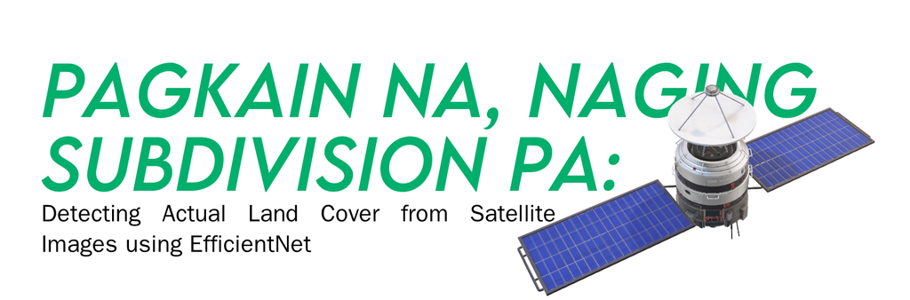

```python
# Helper functions

def show_aid():
    """
    Returns a sample from AID dataset
    """
    directory_path = 'data'

    # List to store image file paths
    image_paths = []

    # Iterate through the directory and its subfolders
    for root, dirs, files in os.walk(directory_path):
        for file in files:
            # Check if the file is an image
            if file.lower().endswith(('.png', '.jpg', '.jpeg', '.gif')):
                # Append the image file path to the list
                image_path = os.path.join(root, file)
                image_paths.append(image_path)

    # Randomly select 30 images from the list
    random_images = random.sample(image_paths, 30)

    # Create a 10x3 grid for displaying the images
    fig, axes = plt.subplots(3, 10, figsize=(12, 4))

    # Iterate over the grid and display the random images
    for i, ax in enumerate(axes.flat):
        # Read and display each image
        image = plt.imread(random_images[i])
        ax.imshow(image)
        ax.axis('off')

    # Adjust the spacing between subplots
    plt.tight_layout()

    # Display the grid of images
    plt.show()


# Define function to plot confusion matrix
def plot_confusion_matrix(confusion_mat, class_labels):
    """
    plot confusion matrix
    """
    plt.imshow(confusion_mat, interpolation='nearest', cmap=plt.cm.Blues)
    plt.title('Confusion Matrix')
    plt.colorbar()
    tick_marks = np.arange(len(class_labels))
    plt.xticks(tick_marks, class_labels, rotation=45)
    plt.yticks(tick_marks, class_labels)
    plt.xlabel('Predicted Label')
    plt.ylabel('True Label')

    thresh = confusion_mat.max() / 2
    for i in range(confusion_mat.shape[0]):
        for j in range(confusion_mat.shape[1]):
            plt.text(j, i, format(confusion_mat[i, j], 'd'),
                     horizontalalignment="center",
                     color="white" if confusion_mat[i, j] > thresh else "black")

    plt.tight_layout()

def show_pcc():
    """
    generate pcc
    """
    # Get the class labels
    class_labels = train_dataset.classes

    # Initialize a dictionary to store the counts
    class_counts = {label: 0 for label in class_labels}

    # Iterate over the train dataset and count the occurrences of each class label
    for _, label in train_dataset:
        class_counts[class_labels[label]] += 1

    # Print the number of items per classification
    list = []
    for label, count in class_counts.items():
        print(f"Class {label}: {count} items")
        list.append(count)

    tot = sum(list)
    answer = 0

    for i in list:
        answer += (i/tot)**(2)

    print(f'\n\nPCC: {answer}')

def data_preprocess():
    data_folder = "data_folder"
    if os.path.exists(data_folder):
        print('Data exists, Skipping action')
    else:
        print("Folder does not exist. Performing the action.")
        # Splitting the Data

        # Define the path to the data folder
        data_folder = 'data'
        output_folder = 'data_folder'

        # Define the train-test-validation split ratios
        test_size = 0.2
        val_size = 0.2

        # Perform the train-test-validation split
        classes = os.listdir(data_folder)
        for class_name in classes:
            class_folder = os.path.join(data_folder, class_name)
            images = os.listdir(class_folder)

            # Split into train and test
            train_images, test_images = train_test_split(images, test_size=test_size, random_state=42)

            # Split the train set into train and val
            train_images, val_images = train_test_split(train_images, test_size=val_size, random_state=42)

            # Create the train, test, and val subfolders in the output folder
            train_folder = os.path.join(output_folder, 'train', class_name)
            test_folder = os.path.join(output_folder, 'test', class_name)
            val_folder = os.path.join(output_folder, 'val', class_name)
            os.makedirs(train_folder, exist_ok=True)
            os.makedirs(test_folder, exist_ok=True)
            os.makedirs(val_folder, exist_ok=True)

            # Move the train images
            for image in train_images:
                src_path = os.path.join(class_folder, image)
                dest_path = os.path.join(train_folder, image)
                shutil.copy(src_path, dest_path)

            # Move the test images
            for image in test_images:
                src_path = os.path.join(class_folder, image)
                dest_path = os.path.join(test_folder, image)
                shutil.copy(src_path, dest_path)

            # Move the val images
            for image in val_images:
                src_path = os.path.join(class_folder, image)
                dest_path = os.path.join(val_folder, image)
                shutil.copy(src_path, dest_path)

def evaluate_model():
    """
    Returns Evaluation Scores and Confusion Matrix
    """
    # Evaluation loop
    model.eval()
    test_predictions = []
    test_labels = []

    with torch.no_grad():
        for images, labels in test_loader:
            images = images.to(device)
            labels = labels.to(device)

            outputs = model(images)
            _, predictions = torch.max(outputs, 1)

            test_predictions.extend(predictions.cpu().numpy())
            test_labels.extend(labels.cpu().numpy())

    # Calculate accuracy, F1 score, and recall
    accuracy = accuracy_score(test_labels, test_predictions)
    f1 = f1_score(test_labels, test_predictions, average='weighted')
    recall = recall_score(test_labels, test_predictions, average='weighted')

    # Calculate confusion matrix
    confusion_mat = confusion_matrix(test_labels, test_predictions)

    print(f'accuracy score: {accuracy}')
    print(f'f1 score: {f1}')
    print(f'recall score: {recall}')

    class_labels = train_dataset.classes
    plot_confusion_matrix(confusion_mat, class_labels)
    return accuracy, f1, recall, confusion_mat

def generate_result():
    """
    Returns a sample result from test set
    """
    # Get the label names from train_dataset.classes
    label_names = train_dataset.classes

    model.eval()
    test_predictions = []
    test_labels = []

    results_dict = {}

    with torch.no_grad():
        for images, labels in test_loader:
            images = images.to(device)
            labels = labels.to(device)

            outputs = model(images)
            _, predictions = torch.max(outputs, 1)

            test_predictions.extend(predictions.cpu().numpy())
            test_labels.extend(labels.cpu().numpy())

            for i in range(len(predictions)):
                if random.random() < 0.01:  # Display 1% of the images
                    image = images[i].cpu().numpy()
                    label = labels[i].cpu().numpy()
                    prediction = predictions[i].cpu().numpy()

                    # Transpose the image channels to correct the color order
                    image = np.transpose(image, (1, 2, 0))

                    # Display the image
                    plt.imshow(image)
                    plt.title(f"Label: {label_names[label]}, Prediction: {label_names[prediction]}")
                    plt.axis('off')
                    plt.show()
```

As we progress with development, one of the challenges Philippines as a country is the balance between land development and progress. Currently, outside the land titles and DENR land classification, the government does not have any other means to confirm if the classification is really observed.

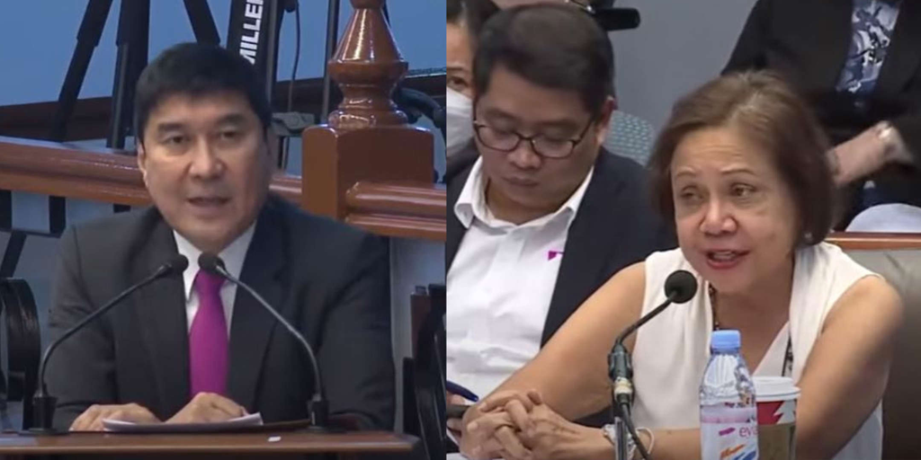

The land use has been a hot topic in recent senate discussion.

Using satellite images, the government can confirm the coverage of the land and take necessary action against its illegal conversion and check which protected farmlands are encroached by developers.

# Why Efficientnet

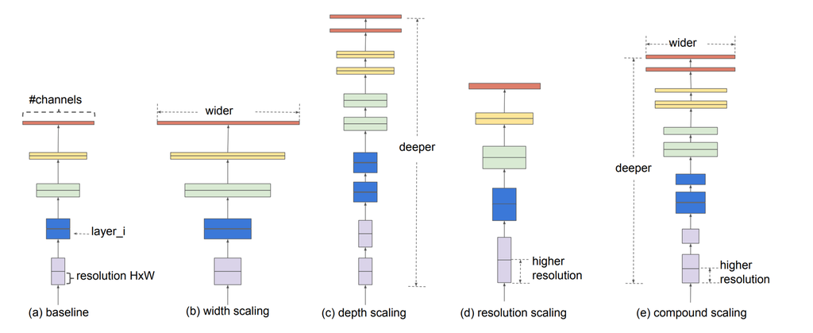

Efficientnet was selected as a model due to two things: Unparalleled Efficiency and State of the Art Accuracy. As an add-in bonus, it can scale seamlessly across different resolutions and input sizes, which is very important for use in satellite images. The reasons are very important since government hardware are not really what we can consider 'state-of-the-art'. Also it is also important that a concerned regular citizen has the means to check for land uses in his or her community.

## Pre-trained Model

Originaly, I used a pretrained efficientnet-b0 model that is extremely lightweight and efficient since it is designed to run on mobile. However this has a problem with transfer learning due to its limited size which results into poor generalizability. With this I used a slightly larger pretrained model, the efficientnet-b1 which works significantly better than the previous one.

On itself, both the models on itself performs really well. However our intended target (dense subdivision and others) are not included into its classification. With this we finetune it and trained it using AID (Aerial Image Dataset).

## Aerial Image Dataset (AID)

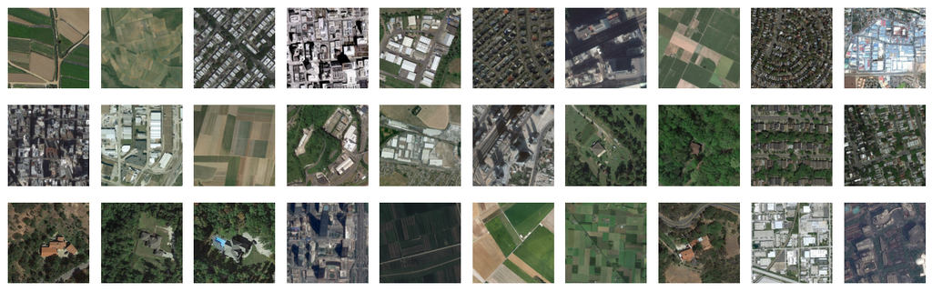

```python
show_aid()
```

AID is a new large-scale aerial image dataset from collected sample images from Google Earth imagery. There are some initial concerns with this dataset since Google Satellite imagery has some color correction added while actual true-color satellite images are not as clear as demonstrated below:

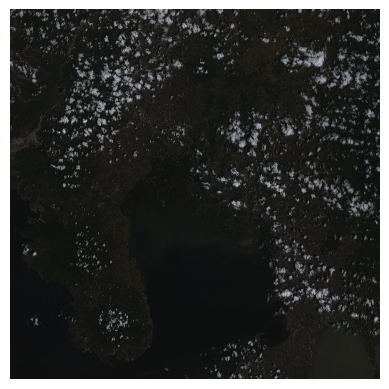

This image was composed using the Bands 2, 3, and 4 of Copernicus Sentinel satellite image. As observed it is not that clear compared to the images that from Google Earth. In the AID's paper, they demonstrated that this is not of concern for training models.

# Fine-Tuning the Model

## Data Preparation

I have prepared a folder named data that contains a labelled dataset from AID. This contains the following folders named after the target classes as follows:

1. Commercial
2. DenseResidential
3. Farmland
4. Industrial
5. SparseResidential

Using the code, a seperate folder was created containing the randomly split data. Toggle the raw code button at the top of the page to see the process with explanation.

```python
data_folder = "data_folder"
if os.path.exists(data_folder):
    print('Data exists, Skipping action')
else:
    print("Folder does not exist. Performing the action.")
    # Splitting the Data

    # Define the path to the data folder
    data_folder = 'data'
    output_folder = 'data_folder'

    # Define the train-test-validation split ratios
    test_size = 0.2
    val_size = 0.2

    # Perform the train-test-validation split
    classes = os.listdir(data_folder)
    for class_name in classes:
        class_folder = os.path.join(data_folder, class_name)
        images = os.listdir(class_folder)

        # Split into train and test
        train_images, test_images = train_test_split(images, test_size=test_size, random_state=42)

        # Split the train set into train and val
        train_images, val_images = train_test_split(train_images, test_size=val_size, random_state=42)

        # Create the train, test, and val subfolders in the output folder
        train_folder = os.path.join(output_folder, 'train', class_name)
        test_folder = os.path.join(output_folder, 'test', class_name)
        val_folder = os.path.join(output_folder, 'val', class_name)
        os.makedirs(train_folder, exist_ok=True)
        os.makedirs(test_folder, exist_ok=True)
        os.makedirs(val_folder, exist_ok=True)

        # Move the train images
        for image in train_images:
            src_path = os.path.join(class_folder, image)
            dest_path = os.path.join(train_folder, image)
            shutil.copy(src_path, dest_path)

        # Move the test images
        for image in test_images:
            src_path = os.path.join(class_folder, image)
            dest_path = os.path.join(test_folder, image)
            shutil.copy(src_path, dest_path)

        # Move the val images
        for image in val_images:
            src_path = os.path.join(class_folder, image)
            dest_path = os.path.join(val_folder, image)
            shutil.copy(src_path, dest_path)
```

```
Folder does not exist. Performing the action.
```

## Training

This model was trained on a midrange machine with the following specs:

- AMD Ryzen 5 5600 6-Core Processor
- RTX 3060 12GB
- 64 GB RAM
- Windows 11 WSL2

Toggle the raw code button at the top of the page to see the process with explanation.

```python
# Set run_again = True to run the model again
run_again = False

if not os.path.exists('model.pth') or run_again == True:
    print('Initializing Training')

    # Set the random seed for reproducibility
    torch.manual_seed(42)

    # Define the transformation to apply to the images
    transform = transforms.Compose([
        transforms.Resize((240, 240)),  # Resize to a slightly larger size for EfficientNet-B1
        transforms.ToTensor(),
        transforms.Normalize(mean=[0.485, 0.456, 0.406], std=[0.229, 0.224, 0.225])  # Use ImageNet mean and std
    ])

    # Load the dataset
    train_dataset = ImageFolder('data_folder/train', transform=transform)
    valid_dataset = ImageFolder('data_folder/val', transform=transform)
    test_dataset = ImageFolder('data_folder/test', transform=transform)

    # Create data loaders
    train_loader = DataLoader(train_dataset, batch_size=32, shuffle=True)
    valid_loader = DataLoader(valid_dataset, batch_size=32, shuffle=False)
    test_loader = DataLoader(test_dataset, batch_size=32, shuffle=False)

    # Load the pre-trained EfficientNet-B1 model
    model = EfficientNet.from_pretrained('efficientnet-b1')
    num_ftrs = model._fc.in_features  # Access the number of input features in the classifier layer
    model._fc = nn.Linear(num_ftrs, len(train_dataset.classes))  # Replace the classifier layer

    # Define the loss function and optimizer
    criterion = nn.CrossEntropyLoss()
    optimizer = optim.Adam(model.parameters(), lr=0.001)

    # Move the model to GPU if available
    device = torch.device("cuda" if torch.cuda.is_available() else "cpu")
    model = model.to(device)

    # Training loop
    num_epochs = 10
    for epoch in range(num_epochs):
        model.train()
        running_loss = 0.0
        progress_bar = tqdm(enumerate(train_loader), total=len(train_loader))

        for batch_idx, (images, labels) in progress_bar:
            images = images.to(device)
            labels = labels.to(device)

            optimizer.zero_grad()

            outputs = model(images)
            loss = criterion(outputs, labels)

            loss.backward()
            optimizer.step()

            running_loss += loss.item() * images.size(0)

            # Update the progress bar
            progress_bar.set_description(f"Epoch {epoch+1}/{num_epochs}")
            progress_bar.set_postfix({"Loss": loss.item()})

        epoch_loss = running_loss / len(train_dataset)
        print(f"Epoch {epoch+1}/{num_epochs} - Loss: {epoch_loss:.4f}")

        # Validation loop
        model.eval()
        num_correct = 0
        num_samples = 0
        with torch.no_grad():
            for images, labels in valid_loader:
                images = images.to(device)
                labels = labels.to(device)

                outputs = model(images)
                _, predictions = torch.max(outputs, 1)

                num_correct += (predictions == labels).sum().item()
                num_samples += labels.size(0)

            accuracy = num_correct / num_samples
            print(f"Validation Accuracy: {accuracy:.4f}")
        # Save the trained model
        torch.save(model, 'model.pth')

else:
    print("Model exists, Skipping action")
```

```
Initializing Training
Loaded pretrained weights for efficientnet-b1
```

```
Validation Accuracy: 0.9122
```

```
Validation Accuracy: 0.8953
```

```
Validation Accuracy: 0.8885
```

```
Validation Accuracy: 0.9020
```

```
Validation Accuracy: 0.9223
```

```
Validation Accuracy: 0.7399
```

```
Validation Accuracy: 0.8784
```

```
Validation Accuracy: 0.9628
```

```
Validation Accuracy: 0.9020
```

```
Validation Accuracy: 0.9358
```

# Evaluation

Let us check the performance against unseen data, our model must beat the PCC scores:

```python
show_pcc()
```

```
Class Commercial: 221 items
Class DenseResidential: 254 items
Class Farmland: 241 items
Class Industrial: 247 items
Class SparseResidential: 193 items


PCC: 0.2018175069742939
```

Here's the result:

```
accuracy score: 0.9565217391304348
f1 score: 0.9564933645244824
recall score: 0.9565217391304348
```

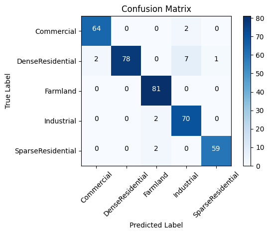

```python
accuracy, f1, recall, confusion_mat = evaluate_model()
```

To sum it up, the model is performing really well and is accurate in its predictions. It can find positive cases with a high level of accuracy.

# Sample Result

```
Clipping input data to the valid range for imshow with RGB data ([0..1] for floats or [0..255] for integers).
```

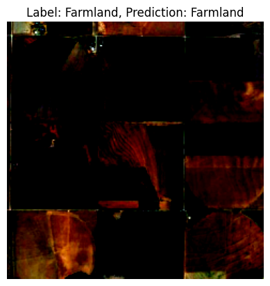

```
Clipping input data to the valid range for imshow with RGB data ([0..1] for floats or [0..255] for integers).
```

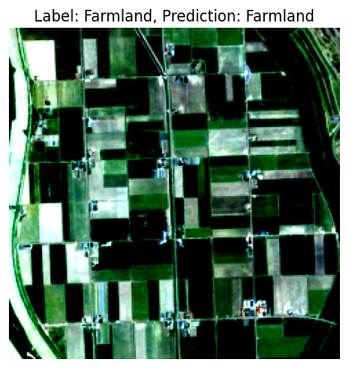

```
Clipping input data to the valid range for imshow with RGB data ([0..1] for floats or [0..255] for integers).
```

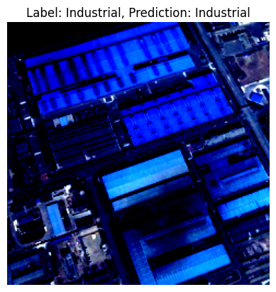

```
Clipping input data to the valid range for imshow with RGB data ([0..1] for floats or [0..255] for integers).
```

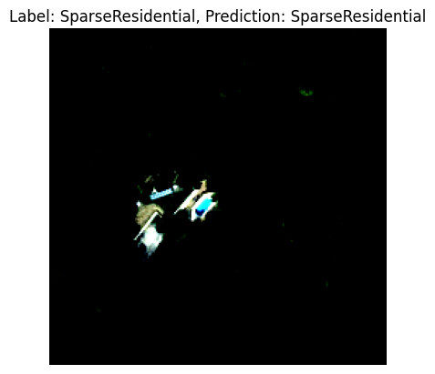

```
Clipping input data to the valid range for imshow with RGB data ([0..1] for floats or [0..255] for integers).
```

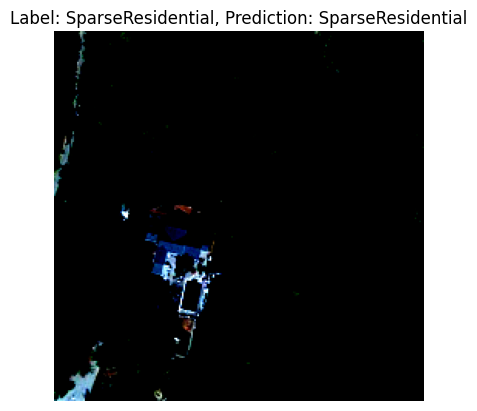

```python
generate_result()
```

# Conclussion

The adoption of EfficientNet as the model for satellite image analysis holds significant potential for government agencies. Its unparalleled efficiency and state-of-the-art accuracy offer substantial advantages in processing large volumes of satellite imagery. The model's ability to seamlessly scale across different resolutions and input sizes is particularly valuable, as it accommodates the limitations of government hardware infrastructure.

Beyond government applications, it is crucial to empower regular citizens with the means to investigate and monitor land uses in their communities. By utilizing EfficientNet for satellite image analysis, concerned citizens can access valuable information about their surroundings, contributing to a better understanding of local land usage patterns and fostering more informed decision-making processes.